# Analysis on isolates used in pairwise competitions

Chang-Yu Chang

2021-12-17

# Introduction

- The R scripts (sourced in this Rmd) can be run externally to Rstudio.
- The R scripts are only for saving R functions, processing raw and temporary data.
- All visualization codes are in this Rmd file.

# 01A isolates experiments

```r
if (run_scripts) source("script/01A-isolates_experiments-01-metadata.R")
```

## Isolate IDs

100 isolates used in the pairwise competition assay, for within-community, across-community, and random assembly. The csv contains:

- `ExpID`: isolation ID used by Djordje. The first and second numbers indicate inoculum and replicates in Goldford2018.
- `ID`: Sanger sequencing ID. Unique ID for sequenced isolates from Sanchez lab.
- `Community`: community ID used in the competition assay.
- `Isolate`: Isolates ID within a community ID, used in the competition assay.

| Assembly | ExpID | ID | Community | Isolate | Family | Genus |
| --- | --- | --- | --- | --- | --- | --- |
| self_assembly | 1.2.A.1 | 259 | C1R2 | 1 | Enterobacteriaceae | Citrobacter |
| self_assembly | 1.2.A.3 | 428 | C1R2 | 2 | Pseudomonadaceae | Pseudomonas |
| self_assembly | 1.2.A.5 | 364 | C1R2 | 3 | Enterobacteriaceae | Serratia |
| self_assembly | 1.2.B.6 | 432 | C1R2 | 4 | Pseudomonadaceae | Pseudomonas |
| self_assembly | 1.4.A.1 | 267 | C1R4 | 1 | Pseudomonadaceae | Pseudomonas |
| self_assembly | 1.4.A.3 | 269 | C1R4 | 2 | Enterobacteriaceae | Enterobacter |
| self_assembly | 1.4.A.4 | 434 | C1R4 | 3 | Pseudomonadaceae | Pseudomonas |
| self_assembly | 1.4.A.5 | 435 | C1R4 | 4 | Enterobacteriaceae | Citrobacter |
| self_assembly | 1.4.B.4 | 270 | C1R4 | 5 | Enterobacteriaceae | Citrobacter |
| self_assembly | 1.6.A.1 | 272 | C1R6 | 1 | Pseudomonadaceae | Pseudomonas |

[output cut: 90 more lines]

## Community metadata

Community IDs and basic information

13 self-assembled communities, two across-community assembly, two random assmebly

```r
communities <- read_csv(here::here("data/output/communities.csv"))
communities
```

| Community | CommunitySize | CommunityPairSize | CommunitiyMotifSize |
| --- | --- | --- | --- |
| C1R2 | 4 | 6 | 4 |
| C1R4 | 5 | 10 | 10 |
| C1R6 | 5 | 10 | 10 |
| C1R7 | 7 | 21 | 35 |
| C2R6 | 4 | 6 | 4 |
| C2R8 | 4 | 6 | 4 |
| C4R1 | 3 | 3 | 1 |
| C7R1 | 4 | 6 | 4 |
| C8R4 | 3 | 3 | 1 |
| C10R2 | 3 | 3 | 1 |

[output cut: 7 more lines]

# 01B isolates sanger sequencing

- Read and align isolate 16S sequences. 1) Read raw `.ab1` file and 2) Merge F and R sequences.
- Classify isolate taxonomy using RDP classifier. `rRDP`
- Align seqeunces using MUSCLE. `msa`
- Build phylogenetic tree by using FastTree or RAxML. `ggtree`

## Install packages

For `R >= 3.5.0`, use `BiocManager::install()` instead of `biocLite()` to install Bioconductor-maintained packages. This may take a few seconds.

```r
install.packages("BiocManager") # Package for managing and installing Bioconductor packages
BiocManager::install("Biostrings") # DNA string format
BiocManager::install("DECIPHER") # Dependent packages of sangeranalyseR
BiocManager::install("sangeranalyseR")
BiocManager::install("sangerseqR") # Align forward and forward Sanger sequences
BiocManager::install("rRDP") # ribosomal database project
BiocManager::install("rRDPData") # 16S Reference database for RDP
BiocManager::install("msa") # Multiple sequence alignment
BiocManager::install("ggtree") # Make figure of phylogenetic tree
install.packages("ape") # Analyses of Phylogenetics and Evolution
```

Attach packages

```r
library(DECIPHER)
library(sangeranalyseR)
library(sangerseqR)
library(rRDP)
library(rRDPData)
library(ggtree)
```

## Read isolate 16S sequences

Read and merge ab1 files

```r
#' This script takes ~10mins to run
#' Do not run this script if `isolates_16S` is already available.
if (run_scripts) source("script/01B-isolate_sanger_seq-01-read_align.R")
```

These isolates include Djordje’s isolates from simplicity paper, and Jean’s isolates from random environments. - `ID`: Sanger sequencing ID. - `Sequence`: Sanger sequence. - `ConsensusLength`:

```r
isolates_16S <- read_csv(here::here("data/temp/isolates_16S.csv"))
isolates_16S
```

| ID | Sequence | ConsensusLength |
| --- | --- | --- |
| 253 | TAGTTGGTGGGGTAAAGGCTCACCAAGGCAACGATCCGTAGCTGGTTTGAGAGGACGACC…… | 913 |
| 254 | GATTGACGTTACCCGCAGAAGAAGCACCGGCTAACTCCGTGCCAGCAGCCGCGGTAATAC…… | 660 |
| 255 | TCACTATTGGAGCGGCCGATATCGGATTAGCTAGTTGGTGGGGTAAAGGCTCACCAAGGC…… | 945 |
| 257 | GGATTAGCTAGTTGGTGGGGTAATGGCTCACCAAGGCGACGATCCGTAACTGGTCTGAGA…… | 928 |
| 258 | TCGGATTAGCTAGTTGGTGGGGTAATGGCTCACCAAGGCGACGATCCGTAACTGGTCTGA…… | 929 |
| 259 | TACGGGAGGCAGCAGTGGGGAATATTGCACAATGGGCGCAAGCCTGATGCAGCCATGCCG…… | 657 |
| 260 | TACGGGAGGCAGCAGTAGGGAATCTTCCGCAATGGACGAAAGTCTGACGGAGCAACGCCG…… | 816 |
| 261 | TGAGAGGATGATCAGTCACACTGGAACTGAGACACGGTCCAGACTCCTACGGGAGGCAGC…… | 861 |
| 262 | TCCCTAGCTGGTCTGAGAGGATGACCAGCCACACTGGAACTGAGACACGGTCCAGACTCC…… | 895 |
| 263 | GAGAGGATGACCAGCCACACTGGAACTGAGACACGGTCCAGACTCCTACGGGAGGCAGCA…… | 880 |

[output cut: 196 more lines]

## Taxonomy classifier

Use RDP taxonomy classifier to determine the isolates’ taxonomy. Assign fermenter/respirator and gram positive/negative according to families.

```r
# This may take a few seconds
if (run_scripts) source("script/01B-isolate_sanger_seq-02-RDP.R")
```

- `ID`
- `Fermenter`: Fermenting sugar or not accroding to the taxanomy
- `GramPositive`: gram positive or negative.
- `Family`
- `Genus`
- `GenusScore`
- `Sequence`

```r
isolates_RDP <- read_csv(here::here("data/temp/isolates_RDP.csv"))
isolates_RDP
```

| ID | Fermenter | GramPositive | Family | Genus | GenusScore | Sequence |
| --- | --- | --- | --- | --- | --- | --- |
| 253 | FALSE | FALSE | Alcaligenaceae | Alcaligenes | 1.00 | TAGTTGGTGGGGTAAAGGCTCACCAAGGCAACGATCCGTAGCTGGTTTGAGAGGACGACC…… |
| 254 | TRUE | FALSE | Enterobacteriaceae | Klebsiella | 0.97 | GATTGACGTTACCCGCAGAAGAAGCACCGGCTAACTCCGTGCCAGCAGCCGCGGTAATAC…… |
| 255 | FALSE | FALSE | Alcaligenaceae | Alcaligenes | 1.00 | TCACTATTGGAGCGGCCGATATCGGATTAGCTAGTTGGTGGGGTAAAGGCTCACCAAGGC…… |
| 257 | FALSE | FALSE | Pseudomonadaceae | Pseudomonas | 1.00 | GGATTAGCTAGTTGGTGGGGTAATGGCTCACCAAGGCGACGATCCGTAACTGGTCTGAGA…… |
| 258 | FALSE | FALSE | Pseudomonadaceae | Pseudomonas | 1.00 | TCGGATTAGCTAGTTGGTGGGGTAATGGCTCACCAAGGCGACGATCCGTAACTGGTCTGA…… |
| 259 | TRUE | FALSE | Enterobacteriaceae | Citrobacter | 0.79 | TACGGGAGGCAGCAGTGGGGAATATTGCACAATGGGCGCAAGCCTGATGCAGCCATGCCG…… |
| 260 | TRUE | FALSE | Bacillaceae 1 | Bacillus | 1.00 | TACGGGAGGCAGCAGTAGGGAATCTTCCGCAATGGACGAAAGTCTGACGGAGCAACGCCG…… |
| 261 | FALSE | FALSE | Pseudomonadaceae | Pseudomonas | 1.00 | TGAGAGGATGATCAGTCACACTGGAACTGAGACACGGTCCAGACTCCTACGGGAGGCAGC…… |
| 262 | TRUE | FALSE | Enterobacteriaceae | Serratia | 1.00 | TCCCTAGCTGGTCTGAGAGGATGACCAGCCACACTGGAACTGAGACACGGTCCAGACTCC…… |
| 263 | TRUE | FALSE | Enterobacteriaceae | Serratia | 0.99 | GAGAGGATGACCAGCCACACTGGAACTGAGACACGGTCCAGACTCCTACGGGAGGCAGCA…… |

[output cut: 185 more lines]

## Multiple sequence alignment and make tree

Save the multiple sequence alignment result, ggtree-compatible tree, and the isolate RDP information with the tree in `data/temp/isolates_sanger_seq.Rdata`.

- `aln`
- `aln2`
- `tree`
- `isolates_seq`

```r
if (run_scripts) source("script/01B-isolate_sanger_seq-03-make_tree.R")
```

```r
load(here::here("data/temp/isolates_sanger_seq.Rdata"))
isolates_seq
```

```
DNAStringSet object of length 195:
      width seq                                                names
  [1]   913 TAGTTGGTGGGGTAAAGGCTCACC...GCACTCTAATGAGACTGCCGGTG 253
  [2]   660 GATTGACGTTACCCGCAGAAGAAG...CTTATCCTTTGTTGCCAGCGGTT 254
  [3]   945 TCACTATTGGAGCGGCCGATATCG...CACTCTAATGAGACTGCCGGTGA 255
  [4]   928 GGATTAGCTAGTTGGTGGGGTAAT...CACTCTAAGGAGACTGCCGGTGA 257
  [5]   929 TCGGATTAGCTAGTTGGTGGGGTA...GCACTCTAAGGAGACTGCCGGTG 258
  ...   ... ...
[191]   882 TGAGAGGATGACCAGCCACACTGG...GAGACTGCCGGTGATAAACCGGA 458
[192]   835 TACGGGAGGCAGCAGTGGGGAATA...GATACTGCCAGTGACAAACTGGA 459
[193]   716 TCCCTAGCTGGTCTGAGAGGATGA...GAACCTTACCTACTCTTGACATC 460
[194]   838 TGAGAGGATGACCAGCCACACTGG...ACCCTTATCCTTTGTTGCCAGCG 461
[195]   676 TACGGGAGGCAGCAGTGGGGAATA...ATGCAGAGAACTTTCCAGAGATG 462
```

67 isolates have Sanger sequences. C2R6 isolate 4 does not have sanger sequence. 68 isolates are used in pairwise competition assays.

Plot basic tree

[figure not shown]

## Pairwise Sanger sequences difference (THIS SECTION IS DEPRECATED)

```r
if (FALSE) source("script/01B-isolate_sanger_seq-04-pairwise_alignment.R")
```

Alignment all possible pairs in the two isolate sets. The alignment result is later used in `05A-random_network_experiment.Rmd` for assembling the community with unambiguous Sanger sequences

# 01C isolates OD and CFU conversion

- Read ODs of isolates and pairs that were measured in pairwise competition experiment. `isolates_OD.csv`
- Read isolates’ CFU on monoculture `isolates_CFU_T8.csv`
- Match isolates’ OD and CFU `isolates_OD_CFU.csv`
- Calculate uncertainty in epsilon using error propagation theory

## Read OD (isolates and pairs)

Read the OD data generated from the analysis script for each experiment batch. The table below is the communities in each experimental batch.

| Experimental batch | Community |
| --- | --- |
| B2 | C11R1 (except for isolate 1), C10R2, C2R6, C2R8, C7R1, C8R4 |
| C | C11R1 isolate 1 (the OD data is in `OD_C2.csv`) |
| C2 | C11R2 |
| D2 | C11R5, C1R2, C1R4, C1R6, C1R7, C4R1 |

Read the OD files and export an overall OD data in csv `output/OD.csv` and an isolate OD csv `output/isolates_OD.csv`

```r
if (run_scripts) source("script/01C-isolates_OD_CFU-01-read_OD.R")
```

Isolate OD at each transfer. Abs values have been averaged out among replicates.

There are 68 isolates used in the pairwise competition experiments.

Write all OD data in `data/temp/OD.csv` and isolate OD in `data/temp/isolates_OD.csv`

```r
isolates_OD <- read_csv(here::here("data/temp/isolates_OD.csv"))
isolates_OD
```

## Read isolates CFU

```r
if (run_scripts) source("script/01C-isolates_OD_CFU-02-read_CFU.R")
```

Colony counts at the given dilution factors.

```r
isolates_CFU_T8
```

```r
isolates_OD_CFU
```

There are 68 isolates used in the pairwise competition experiments.

Write isolate OD and CFU in `data/temp/isolates_OD_CFU.csv`

## Epsilon: OD-CFU conversion coefficient

```r
if (run_scripts) source("script/01C-isolates_OD_CFU-03-epsilon.R")
```

To determine the outcomes of pairwise competition, I compare the frequencies changes between T1 and T8, which were empirically measured at different approaches and have to be converted into the same unit for comparison.

- T1 frequencies are determined by mixing two isolate inocula with the standardized OD (OD620 = 0.1) at three initial frequencies: 5:95, 50:50, 95:5. T1 frequencies are thus OD frequencies.
- T8 frequencies are determined by plating the mature media (48 hour growth cycle) on rich agar plates and counting the colony of each isolate. T8 frequencies are thus CFU frequencies.

In this section, I convert the OD frequencies at T1 to CFU frequencies. For each isolate, the CFU and OD have the following relationships.

$$CFU_A = \frac{OD_A DF_A v_A}{\epsilon_A}$$

```r
isolates_epsilon
```

# 01D isolates growth rates

```r
if (run_scripts) source("script/01D-isolates_growth_rate-01-read_data.R")
```

```r
isolates_growth_traits <- read_csv(here::here("data/temp/isolates_growth_traits.csv"))
```

`isolates_growth_traits` contains many columns. CS is a wildcard for any carbon source measured. - `r_CS_*hr`: growth rates on carbon sources at 12, 16, 28, 48 hr, measured from the growth curve data. Data from Sylvie `data/raw/growth_rate/raw_gcurves_all_sylvies.csv`. - `X_CS_*hr`: secreted acids (acetate, lactate, succinate) amount at 0, 16, 28, 48 hr. Data from Sylvie `data/raw/growth_rate/Estrela_2021_isolates_ph_OAs.csv` - `pH_*hr`: pH measured at 0, 16, 28, 48 hr. Data from Sylvie `data/raw/growth_rate/Estrela_2021_isolates_ph_OAs.csv`. - `PreferredCS` and `SecretedCS`: acid preference determined by the sequence of acid used, manually corrected by eyeballing the figure `01D-byproduct_conc.png`. Data from Sylvie `data/raw/growth_rate/Estrela_2021_isolates_ph_OAs.csv`. - `ByproductSum_*hr`: sum of acids produced at 0, 16, 28, 48 hr. Data from Sylvie `data/raw/growth_rate/raw_gcurves_all_sylvies`.

## Acids production over time

```r
coeff <- 5
p <- isolates_growth_traits %>%
    mutate(ID = factor(ID)) %>%
    filter(!all(acetate_mM == 0), !all(lactate_mM == 0), !all(succinate_mM == 0)) %>%
    ggplot() +
    geom_line(aes(x = Time, y = acetate_mM, color = "acetate")) +
    geom_point(aes(x = Time, y = acetate_mM, color = "acetate")) +
    geom_line(aes(x = Time, y = lactate_mM * coeff, color = "lactate")) +
    geom_point(aes(x = Time, y = lactate_mM * coeff, color = "lactate")) +
    geom_line(aes(x = Time, y = succinate_mM * coeff, color = "succinate")) +
    geom_point(aes(x = Time, y = succinate_mM * coeff, color = "succinate")) +
    geom_text(data = isolates_preference, aes(label = PreferredCS), x = 8, y = Inf, size = 2, vjust = 1) +
    scale_y_continuous(name = "acetate (mM)", sec.axis = sec_axis(~./coeff, name = "lactate (mM) or succinate (mM)")) +
    scale_color_manual(values = c("acetate" = "red", "lactate" = "green", "succinate" = "blue")) +
    facet_wrap(.~ID, scales = "free_y") +
    theme_bw() +
    theme(legend.position = "top") +
    labs(x = "Time", color = "")

ggsave("figure/01D-byproduct_conc.png", plot = p, width = 20 , height = 10)
```

# 01E match isolates to ESV for community abundanuce

[ ] check the ambiguous characters for matching ESV and Sangers

Read community sequences

```r
if (run_scripts) source("script/01E-match_community_abundance-01-community_sequence.R")
```

OTU table output `communities_abundance_syl` comes from the curated community ESV table from Sylvie.

I formatted the data.frame so that both of them have the following variables:

- `SampleID`: experiment ID used by Nanxi or Sylvie.
- `Community`: community, for instance, C2R4 or C1Rpool.
- `Transfer`: the transfer when the community was sequenced.
- `Adundance`: the number of this sequence in the community.
- `RelativeAbundance`
- `CommunityESVID`: the sequence identifier. This identifier is community-sequence specific.
- `ESV`: the DNA sequence in 16s V4 region.

In `communities_abundance_syl`, there are other parameters

- `CarbonSource`: the carbon source used for assembly
- `Order`, `Family`, and `Genus`: SILVA assigned taxonomy

```r
communities_abundance_syl <- read_csv(here::here("data/temp/communities_abundance_syl.csv"))
communities_abundance_syl
```

## Match community ESVs and isolate Sanger sequences

```r
# It may take 10 mins
if (run_scripts) source("script/01E-match_community_abundance-02-match_isolate_16S.R")
```

IUPAC notation for DNA base pairs

W, S, M, K, R, Y represent two possiblities for one base pair B, D, H, V represent three possiblities N means any nucleotides (but not a gap)

I tested five alignment methods in `Biostrings::pairwiseAlignment()`

```r
sequences_alignment_syl <- read_csv(here::here("data/temp/sequences_alignment_syl.csv"))
sequences_alignment_syl
```

```r
# R function for computing distinct Sanger
distinct_sanger <- function(x, allow_mismatch = 2) {
  x %>%
    # Filter for BasePairMatch
    filter(BasePairMismatch <= allow_mismatch) %>%
    # For each Sanger, find the Sanger-ESV match with highest alignment score
    group_by(AlignmentType, ExpID) %>%
    arrange(desc(AlignmentScore)) %>%
    dplyr::slice(1) %>%
    ungroup() %>%
    # Remove duplicates that matches two Sangers to one ESV
    group_by(AlignmentType, Community, CommunityESVID) %>%
    distinct(RelativeAbundance, .keep_all = T) %>%
    arrange(Community) %>%
    # Specify mismatch allowed
    mutate(AllowMismatch = allow_mismatch) %>%
    group_by(AlignmentType) %>%
    summarize(Count = n())
}

x <- sequences_alignment_syl
# R function for matched isolate Sanger
"
finish this function
"

matched_sanger <- function (x, allow_mismatch = 2) {
  x %>%
     # Filter for BasePairMatch
    filter(BasePairMismatch <= allow_mismatch) %>%
    # For each Sanger, find the Sanger-ESV match with highest alignment score
    group_by(AlignmentType, ExpID) %>%
    arrange(desc(AlignmentScore)) %>%
    dplyr::slice(1) %>%
    ungroup() %>%
    # Remove duplicates that matches two Sangers to one ESV
    group_by(AlignmentType, Community, CommunityESVID) %>%
    distinct(RelativeAbundance, .keep_all = T) %>%
    arrange(Community) %>%
    # Specify mismatch allowed
    mutate(AllowMismatch = allow_mismatch) %>%
    group_by(AlignmentType) %>%
    summarize(Count = n())
}
```

Number of isolates being matched to the community ESV if we allow for up to two mismatches.

```r
distinct_sanger(sequences_alignment_syl, allow_mismatch = 2)
```

Up to one mismatch

```r
distinct_sanger(sequences_alignment_syl, allow_mismatch = 1)
```

No mismatch

```r
distinct_sanger(sequences_alignment_syl, allow_mismatch = 0)
```

## Relative abundance explained by the sequences

```r
if (run_scripts) source("script/01E-match_community_abundance-03-matched_abundance.R")
```

ESV abundances for all 96 communities

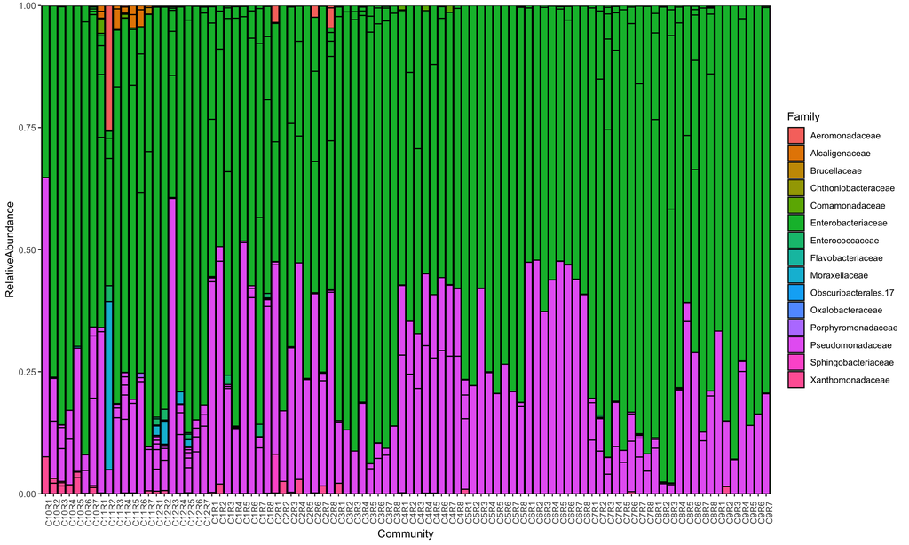

```r
plot_abundance <- function(df, label_x = "Community", label_y = "RelativeAbundance", fill = "CommunityESVID") {
  ggplot(df) +
    geom_bar(aes_string(x = label_x, y = label_y, fill = fill),
      position = "stack", stat = "identity", col = 1) +
    theme_bw() +
    theme(axis.text.x = element_text(angle = 90)) +
    scale_y_continuous(expand = c(0, 0))
}

communities_abundance_syl <- read_csv(here::here("data/temp/communities_abundance_syl.csv"))
communities_abundance_syl %>%
  filter(CarbonSource == "Glucose") %>%
  plot_abundance(label_x = "Community", label_y = "RelativeAbundance", fill = "Family")
```

ESV abundances of 13 communities used in the competition assay

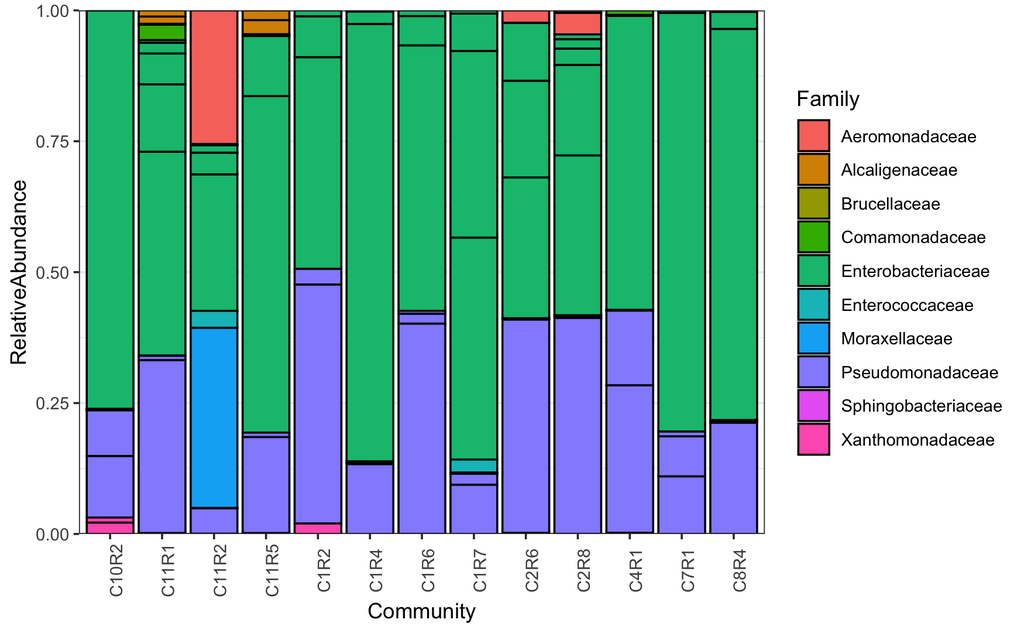

Abundances of ESVs matched to Sangers.

```r
sequences_abundance <- read_csv(here::here("data/temp/sequences_abundance.csv"))
# Color sets from Sylvie
color_sets <- tibble(Color = c("yellow", "deepskyblue3", "blue", "darkorchid2", "firebrick", "orange2", "grey"),
  Family = c("Aeromonadaceae", "Enterobacteriaceae", "Moraxellaceae", "Pseudomonadaceae","Comamonadaceae","Alcaligenaceae", "Sphingobacteriaceae"))

p <- sequences_abundance %>%
  filter(AlignmentType == "local") %>%
  filter(AllowMismatch == Inf) %>%
  filter(BasePairMismatch <= 4) %>%
  mutate(Community = ordered(Community,  communities$Community)) %>%
  plot_abundance(label_x = "Community", label_y = " RelativeAbundance", fill = "Family") +
  labs(x = "", y = "Relative abundance") +
  scale_fill_manual(values = setNames(color_sets$Color, color_sets$Family)) +
  scale_x_discrete(expand=c(0,0)) +
  scale_y_continuous(expand=c(0,0), limits = c(0,1), breaks = seq(0,1, .25)) +
  NULL
p
ggsave("figure/01E-isolate_abundance.png", p, width = 6, height = 4)
```

```r
sequences_abundance %>%
  mutate(AllowMismatch = paste0("AllowMismatch: ", AllowMismatch)) %>%
  plot_abundance(label_x = "Community", label_y = "RelativeAbundance", fill = "Family") +
  facet_grid(AllowMismatch~AlignmentType) +
  theme(legend.position = "top")
```

# Summary

## Combine and generate the isolate metadata file

```r
if (run_scripts) source("script/01-isolates-01-read_match_isolate.R")
```

```r
str(isolates)
```

```
spec_tbl_df [100 × 68] (S3: spec_tbl_df/tbl_df/tbl/data.frame)
 $ Assembly           : chr [1:100] "self_assembly" "self_assembly" "self_assembly" "self_assembly" ...
 $ ExpID              : chr [1:100] "1.2.A.1" "1.2.A.3" "1.2.A.5" "1.2.B.6" ...
 $ ID                 : num [1:100] 259 428 364 432 267 269 434 435 270 272 ...
 $ Community          : chr [1:100] "C1R2" "C1R2" "C1R2" "C1R2" ...
 $ Isolate            : num [1:100] 1 2 3 4 1 2 3 4 5 1 ...
 $ Fermenter          : logi [1:100] TRUE FALSE TRUE FALSE FALSE TRUE ...
 $ GramPositive       : logi [1:100] FALSE FALSE FALSE FALSE FALSE FALSE ...
 $ Family             : chr [1:100] "Enterobacteriaceae" "Pseudomonadaceae" "Enterobacteriaceae" "Pseudomonadaceae" ...
 $ Genus              : chr [1:100] "Citrobacter" "Pseudomonas" "Serratia" "Pseudomonas" ...
 $ GenusScore         : num [1:100] 0.79 1 1 1 1 0.92 1 0.73 0.76 1 ...
 $ Sequence           : chr [1:100] "TACGGGAGGCAGCAGTGGGGAATATTGCACAATGGGCGCAAGCCTGATGCAGCCATGCCGCGTGTATGAAGAAGGCCTTCGGGTTGTAAAGTACTTTCAGCGAGGAGGAAG"| __truncated__ "TCGGATTAGCTAGTTGGTGAGGTAATGGCTCACCAAGGCGACGATCCGTAACTGGTCTGAGAGGATGATCAGTCACACTGGAACTGAGACACGGTCCAGACTCCTACGGGA"| __truncated__ "TAGGC…
 $ ColonyCount        : num [1:100] 81 91 132 184 65 106 0 29 41 49 ...
 $ DilutionFactor     : num [1:100] 5 5 5 5 5 5 3 5 5 5 ...
 $ Epsilon            : num [1:100] 3.44e-07 4.38e-07 2.38e-07 1.71e-07 4.72e-07 ...
 $ Win                : num [1:100] 2 0 2 0 0 2 0 2 2 0 ...
 $ Lose               : num [1:100] 0 2 0 2 3 0 3 0 0 3 ...
 $ Draw               : num [1:100] 1 1 1 1 1 2 1 2 2 1 ...
 $ Score              : num [1:100] 2 -2 2 -2 -3 2 -3 2 2 -3 ...
 $ Game               : num [1:100] 3 3 3 3 4 4 4 4 4 4 ...
 $ Rank               : num [1:100] 1 3 1 3 4 1 4 1 1 5 ...
 $ PlotRank           : num [1:100] 1 3 2 4 4 1 5 2 3 5 ...
 $ rmid_ketogluconate : num [1:100] 0.1014 0.0191 0.0834 0.07 0.0585 ...
 $ rmid_acetate       : num [1:100] 0.0157 0.0386 0.0104 0.0512 0.021 ...
 $ rmid_glucose       : num [1:100] 0.1382 0.0813 0.1093 0.0832 0.0156 ...
 $ rmid_lactate       : num [1:100] 0.0825 0.0869 0.007 0.0586 0.1014 ...
 $ rmid_gluconate     : num [1:100] 0.1384 0.0848 0.1204 0.0913 0.0666 ...
 $ rmid_succinate     : num [1:100] 0.0766 0.091 0.073 0.0866 0.1106 ...
 $ rmax_lactate       : num [1:100] 0.365 0.646 0.585 0.878 0.666 ...
 $ rmax_succinate     : num [1:100] 0.347 0.372 0.303 0.574 0.808 ...
 $ rmax_glucose       : num [1:100] 1.198 0.661 0.496 0.408 0.681 ...
 $ rmax_acetate       : num [1:100] 0.156 0.414 0.265 0.639 0.312 ...
 $ X_acetate_0hr      : num [1:100] 0 0 0 0 0 0 NA 0 0 0 ...
 $ X_acetate_16hr     : num [1:100] 10.49 0 6.65 0 0 ...
 $ X_acetate_28hr     : num [1:100] 17.938 0.247 6.651 0.295 0.464 ...
 $ X_acetate_48hr     : num [1:100] 26.2103 0.4475 4.498 0.1178 0.0707 ...
 $ X_succinate_0hr    : num [1:100] 0 0 0 0 0 0 NA 0 0 0 ...
 $ X_succinate_16hr   : num [1:100] 0.46009 0.00195 0.81544 0.00562 0.01113 ...
 $ X_succinate_28hr   : num [1:100] 0.44069 0.00798 0.73257 0.01192 0.01611 ...
 $ X_succinate_48hr   : num [1:100] 0.30852 0.01008 0.00221 0.02162 0.02005 ...
```

[output cut: 86 more lines]

```
  ..   OD620_16h_citrate = col_double(),
  ..   OD620_16h_succinate = col_double(),
  ..   OD620_16h_fumarate = col_double(),
  ..   OD620_16h_acetate = col_double(),
  ..   pH_0hr = col_double(),
  ..   pH_16hr = col_double(),
  ..   pH_28hr = col_double(),
  ..   pH_48hr = col_double(),
  ..   PreferredCS = col_character(),
  ..   SecretedCS = col_character(),
  ..   leakiness_16hr = col_double(),
  ..   leakiness_28hr = col_double(),
  ..   leakiness_48hr = col_double()
  .. )
 - attr(*, "problems")=<externalptr>
```

## Plot isolates’ functions

### Growth rates on varied CSs

```r
isolates %>%
    select(ID, Fermenter, starts_with("r_")) %>%
    pivot_longer(cols = c(-Fermenter, -ID), names_prefix = "r_", names_to = "CS", values_to = "r") %>%
    mutate(CS = factor(CS, c("glucose", "acetate", "lactate", "succinate", "gluconate", "ketogluconate"))) %>%
    filter(!is.na(Fermenter)) %>%
    ggplot() +
    geom_histogram(aes(x = r, fill = Fermenter), color = 1, binwidth = 0.005) +
    facet_wrap(.~CS, nrow = 3, scales = "free_y") +
    theme_classic()
```

### OD at 16hr on varied CSs

```r
isolates %>%
    select(ID, Fermenter, starts_with("OD")) %>%
    pivot_longer(cols = c(-Fermenter, -ID), names_prefix = "OD620_16h_", names_to = "CS", values_to = "r") %>%
    mutate(CS = factor(CS, c("glucose", "acetate", "succinate", "citrate", "fructose", "arabinose", "galactose", "ribose", "glycerol", "pyruvate", "malate", "fumarate"))) %>%
    filter(!is.na(Fermenter)) %>%
    ggplot() +
    geom_histogram(aes(x = r, fill = Fermenter), color = 1, binwidth = 0.01) +
    facet_wrap(.~CS, nrow = 4, scales = "free_y") +
    theme_classic()
```

### Acids production

```r
isolates %>%
    select(ID, Fermenter, starts_with("X_"), starts_with("pH")) %>%
    pivot_longer(cols = c(-Fermenter, -ID), names_prefix = "X_", names_sep = "_", names_to = c("CS", "Time"), values_to = "Amount") %>%
    mutate(Time = sub("hr", "", Time)) %>%
    mutate(CS = factor(CS, c("pH", "acetate", "lactate", "succinate"))) %>%
    filter(!is.na(Fermenter)) %>%
    ggplot() +
    geom_line(aes(x = Time, y = Amount, group = ID, color = Fermenter)) +
    facet_wrap(.~CS, nrow = 2, scales = "free_y") +
    theme_classic()
```

### Total acid production

```r
isolates %>%
    select(ID, Fermenter, starts_with("Byproduct")) %>%
    pivot_longer(cols = c(-Fermenter, -ID), names_prefix = "ByproductSum_", names_to = "Time", values_to = "Amount") %>%
    mutate(Time = sub("hr", "", Time)) %>%
    filter(!is.na(Fermenter)) %>%
    ggplot() +
    geom_line(aes(x = Time, y = Amount, group = ID, color = Fermenter)) +
    #facet_wrap(.~CS, nrow = 2, scales = "free_y") +
    theme_classic()
```

## Plot isolates’ tree

```r
source("script/01-isolates-03-tree.R")
```